# Take Home Assignment 2 (Faizal)

DLPI 2D Customer Analytics (Batch 9)

2026-02-08

# Case Scenario: Library Usage Analysis

A university library has been tracking visits made by users over the past few months. Each record includes user demographics, visit duration, and number of books borrowed. Your task is to use RFM analysis (Recency, Frequency, and “Monetary” in terms of total books borrowed) to segment users and generate actionable insights for improving library engagement.

Answer the following questions using the dataset `library_visits_THA2.xlsx`. Show your code and interpretations clearly.

```r
pacman::p_load(dplyr, lubridate, readxl, ggplot2)
```

```r
#Import the library dataset
df <- read_xlsx("../data/library_visits_THA2.xlsx")
str(df)
```

```
## tibble [1,020 × 7] (S3: tbl_df/tbl/data.frame)
##  $ UserID      : chr [1:1020] "G64109281S" "G90017809U" "G38653767G" "G98457512S" ...
##  $ Date        : POSIXct[1:1020], format: "2025-07-30" "2025-07-30" ...
##  $ Duration    : num [1:1020] 163 194 78 210 178 98 230 84 42 35 ...
##  $ BookBorrowed: num [1:1020] 0 0 0 0 0 2 1 0 0 0 ...
##  $ Gender      : chr [1:1020] "Female" "Male" "Female" "Male" ...
##  $ Age         : num [1:1020] 19 20 23 20 17 17 21 20 23 20 ...
##  $ Faculty     : chr [1:1020] "NUSC" "Med" "SOC" "SOC" ...
```

# Q1. Preprocess the dataset and calculate RFV metrics for each user. Assign 1–3 scores for Recency, Frequency, and Volume using tertiles, and store the results in a new dataframe called `df_rfv`

1. Recency: Days since last visit (assume today is “2025-07-30”)
2. Frequency: Number of visits
3. Volume: Total books borrowed

```r
# Set reference date
reference_date <- as.Date('2025-07-30')

#Change variables in character format to factor
df <- df %>% mutate_if(is.character,as.factor)
str(df)
```

```
## tibble [1,020 × 7] (S3: tbl_df/tbl/data.frame)
##  $ UserID      : Factor w/ 454 levels "G10244076I","G10394751R",..: 259 400 129 447 224 315 4 215 320 230 ...
##  $ Date        : POSIXct[1:1020], format: "2025-07-30" "2025-07-30" ...
##  $ Duration    : num [1:1020] 163 194 78 210 178 98 230 84 42 35 ...
##  $ BookBorrowed: num [1:1020] 0 0 0 0 0 2 1 0 0 0 ...
##  $ Gender      : Factor w/ 2 levels "Female","Male": 1 2 1 2 2 1 1 1 1 2 ...
##  $ Age         : num [1:1020] 19 20 23 20 17 17 21 20 23 20 ...
##  $ Faculty     : Factor w/ 6 levels "FASS","FOS","LAW",..: 5 4 6 6 6 1 6 4 1 4 ...
```

```r
# Change Date column to Date object in Year-Month-Day format ("YYYY-MM-DD")
df$Date <- ymd(df$Date)
str(df)
```

```
## tibble [1,020 × 7] (S3: tbl_df/tbl/data.frame)
##  $ UserID      : Factor w/ 454 levels "G10244076I","G10394751R",..: 259 400 129 447 224 315 4 215 320 230 ...
##  $ Date        : Date[1:1020], format: "2025-07-30" "2025-07-30" ...
##  $ Duration    : num [1:1020] 163 194 78 210 178 98 230 84 42 35 ...
##  $ BookBorrowed: num [1:1020] 0 0 0 0 0 2 1 0 0 0 ...
##  $ Gender      : Factor w/ 2 levels "Female","Male": 1 2 1 2 2 1 1 1 1 2 ...
##  $ Age         : num [1:1020] 19 20 23 20 17 17 21 20 23 20 ...
##  $ Faculty     : Factor w/ 6 levels "FASS","FOS","LAW",..: 5 4 6 6 6 1 6 4 1 4 ...
```

```r
#Check for missing values
sum(is.na(df))
```

```
## [1] 0
```

```r
# To identify specific rows with missing values
df[rowSums(is.na(df)) > 0, ]
```

```
## # A tibble: 0 × 7
## # ℹ 7 variables: UserID <fct>, Date <date>, Duration <dbl>, BookBorrowed <dbl>,
## #   Gender <fct>, Age <dbl>, Faculty <fct>
```

```r
#Check for duplicates
sum(duplicated(df))
```

```
## [1] 0
```

```r
#Compute Recency (days since last visit)
df_recency <- df %>%
  group_by(UserID) %>%
  summarise(Recency = as.numeric(reference_date - max(Date)))

#Compute Frequency (number of visits per customer)
df_frequency <- df %>%
  group_by(UserID) %>%
  summarise(Frequency = n())

#Compute Volume per customer
df_volume <- df %>%
  group_by(UserID) %>%
  summarise(Volume = sum(BookBorrowed, na.rm = TRUE))

#Merge all three metrics into a single dataframe
df_rfv <- df_recency %>%
  inner_join(df_frequency, by = "UserID") %>%
  inner_join(df_volume, by = "UserID")

#Assign tertiles-based scores (1, 2, 3)
df_rfv <- df_rfv %>%
  mutate(Recency_Score = ntile(Recency, 3),
    Frequency_Score = ntile(Frequency, 3),
    Volume_Score = ntile(Volume, 3)
    )

#Adjust Recency Score so that lower recency gets higher score
df_rfv$Recency_Score <- 4 - df_rfv$Recency_Score  # Convert 1→3, 2→2, 3→1
```

# Q2. Based on RFV scores, segment users from `df_rfv` into the following 6 categories based on the order listed below and report the number of users in each category:

- Avid Readers: R: 3, F: 3, V: 3
- Consistent Borrowers: R: 2-3, F: 2-3, V: 2-3
- Newcomers: R: 3, F: 1-2, V: 1-2
- At-Risk Users: R: 1-2, F: 2-3, V: 2-3
- Inactive: R: 1-2, F: 1-2, V: 1-2
- Others: all the rest

```r
# Segments are assigned hierarchically in the order listed to avoid overlap
#Assign customer segments based on RFD scores
df_rfv <- df_rfv %>%
  mutate(
    Segment = case_when(
      Recency_Score >= 3 & Frequency_Score >= 3 & Volume_Score >= 3 ~ "Avid Readers",
      Recency_Score >= 2 & Frequency_Score >= 2 & Frequency_Score <= 3 & Volume_Score >= 2 & Volume_Score <= 3 ~ "Consistent Borrowers",
      Recency_Score == 3 & Frequency_Score <= 2 & Volume_Score <= 2 ~ "Newcomers",
      Recency_Score <= 2 & Frequency_Score >= 2 & Volume_Score >= 2 ~ "At-Risk Users",
      Recency_Score >= 1 & Recency_Score <= 2 & Frequency_Score >= 1 & Frequency_Score <= 2 &
        Volume_Score >= 1 & Volume_Score <= 2 ~ "Inactive",
      TRUE ~ "Others"
    )
  )


table(df_rfv$Segment)
```

```
##
##        At-Risk Users         Avid Readers Consistent Borrowers
##                   45                   44                  140
##             Inactive            Newcomers               Others
##                  147                   33                   45
```

```r
# You should get this output:
       # At-Risk Users         Avid Readers Consistent Borrowers             Inactive        #            45                   44                  140                  147        #     Newcomers               Others
       #            33                   45
```

# Q3. Visualise the RFV segments using a bar chart and interpret the visualisation. Provide your interpretation in at least 30 words.

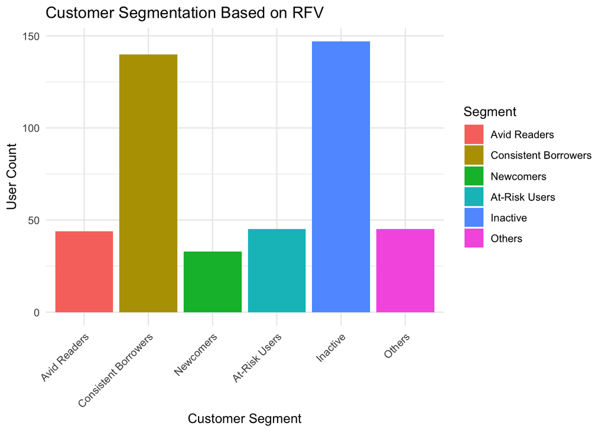

```r
order <- c("Avid Readers", "Consistent Borrowers", "Newcomers", "At-Risk Users", "Inactive", "Others")

df_rfv$Segment <- factor(df_rfv$Segment, levels = order)

ggplot(df_rfv, aes(x = Segment, fill = Segment)) +
  geom_bar() +
  labs(title = "Customer Segmentation Based on RFV",
       x = "Customer Segment",
       y = "User Count") +
  theme_minimal() +
  theme(axis.text.x = element_text(angle = 45, hjust = 1))
```

```r
#Add your interpretation here
#Inactive is the largest group followed by Consistent Borrowers, showing that there are almost  many regular users who use it often. The other groups, such as Avid Readers, At-Risk Users, and Newcomers, are smaller, which suggests that while there is a strong group of active users, there is also a need to encourage inactive and at-risk users to come back and stay engaged.
```